# Self-Driving Car Engineer Nanodegree

## Project: Build a Traffic Sign Recognition Classifier

### By Anthony Knight April 24, 2017

#### Code cell 1: Let's Load The Data

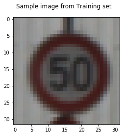

```python
import pickle
import csv

training_file =  'traffic-signs-data/train.p'
validation_file= 'traffic-signs-data/valid.p'
testing_file =   'traffic-signs-data/test.p'

with open(training_file, mode='rb') as f:
    train = pickle.load(f)
    f.close()
with open(validation_file, mode='rb') as f:
    valid = pickle.load(f)
    f.close()
with open(testing_file, mode='rb') as f:
    test = pickle.load(f)
    f.close()

X_train, y_train = train['features'], train['labels']
X_valid, y_valid = valid['features'], valid['labels']
X_test, y_test = test['features'], test['labels']
X_sizes = train['sizes'] #did not use this
X_coords = train['coords'] #did not use this

lookup_file = 'signnames.csv'
with open(lookup_file) as csvfile:
    reader = csv.DictReader(csvfile)
    signtypes = {}
    for row in reader:
        key = row.pop('ClassId')
        if key in signtypes:
            pass
        signtypes[key] = row.pop('SignName')

import matplotlib.pyplot as plt
import numpy as np

plt.imshow(X_train[np.random.randint(len(X_train))])
plt.suptitle("Sample image from Training set")
```

#### Code Cell 2: Let's set up some Helper Functions to process and display images

```python
## Cell with helper functions
import pandas as pd
import numpy as np
import cv2
import skimage as sk
import skimage.exposure as exp
from skimage.color import rgb2gray
import matplotlib.pyplot as plt

test_helperfuncs = False #set to true to test funcs

## Send in an RGB image - get back a greyscale image that has been
## Contrast Limited Adaptive histogram equalized
## image returned as 32*32 and 32*32*1
def imagepipeline(img, clahe='cv2', cliplimit=32, tiles=4):
    #print(clahe)
    if clahe == 'ski':
        img = sk.img_as_float(img)
        img = rgb2gray(img)
        #img = sk.exposure.equalize_adapthist(image, kernel_size=None, clip_limit=0.01, nbins=256, **kwargs)
        if cliplimit < 0. or cliplimit >1.:
            print("out of bounds cliplimit for equalize_adapthist -setting to {}.".format(0.01))
            cliplimit = 0.01
        img = sk.img_as_ubyte(exp.equalize_adapthist(img, kernel_size=tiles, clip_limit=cliplimit, nbins=64))
        #img = img.reshape((32, 32))
        imgr = img.reshape((32, 32, 1))
        return(img, imgr)
    else:# clahe == 'cv2':
        img = cv2.cvtColor(img, cv2.COLOR_RGB2GRAY)
        clahe = cv2.createCLAHE(clipLimit=cliplimit, tileGridSize=(tiles,tiles))
        img = clahe.apply(img)
        imgr = img.reshape((32, 32, 1))
        return(img, imgr)

#Add a graynoise border to image using a random grayscale pallette obtained from original image
def graynoise_border(img, border_width=8):
    x_dim = img.shape[0]+2*border_width
    y_dim = img.shape[1]+2*border_width
    graynoise = np.random.choice(img.flatten(), size=(x_dim,y_dim))
    #put image on before blur to mix noise into edge, then reapply orig image
    graynoise[border_width:border_width+img.shape[0],border_width:border_width+img.shape[1]] = img
    graynoise = cv2.GaussianBlur(graynoise,(3,3),0)
    #graynoise = np.random.random_integers(255, size=(x_dim,y_dim))
    graynoise[border_width:border_width+img.shape[0],border_width:border_width+img.shape[1]] = img
    return(graynoise)

# helper to plot a small
def plot_image(img, img_title, sizex=3, sizey=3, cmap='gray'):
    fig1 = plt.figure(figsize=(sizex,sizey))
    ax1 = fig1.add_subplot(1,1,1)
    ax1.set_title(img_title)
    plt.imshow(img, cmap=cmap)
    plt.show()


if test_helperfuncs == True:
    cl1, cl1r = imagepipeline(X_train[10], clahe='ski', tiles=16, cliplimit = .15)
    cl2, cl2r = imagepipeline(X_train[10], clahe='cv2')
    img2 = graynoise_border(cl1,8)
    plot_image(cl1, "skimage", sizex=5, sizey=5)
    plot_image(cl2, "cv2", sizex=5, sizey=5)
    plot_image(img2,"gray noise_border",sizex=5, sizey=5)
```

#### Code Cell 3: Now let's calculate some statistics on the image sets based on the sign types and the pixel intensities

```python
##Flag to decide which way to process images skimage or cv2
use_skimage = False # skimage did not work as well as cv2 for adaptive equalization during experiments

lookup_file = 'signnames.csv'

#read in dictionary of the sign id and signname from the csv
signtypes = {}
with open(lookup_file) as csvfile:
    reader = csv.DictReader(csvfile)
    for row in reader:
        key = row.pop('ClassId')
        if key in signtypes:
            # implement any duplicate row handling here
            pass
        signtypes[key] = row.pop('SignName')

signnames= []
for i in range(len(signtypes)):
    num = "{}".format(i)
    signnames.append(signtypes[num])

# Get count of training examples
n_train = len(X_train)
n_valid = len(X_valid)
# Get count of testing examples.
n_test = len(X_test)

# Determine the shape of traffic sign image
image_shape = X_train[0].shape

# Determine how many unique classes/labels are in the dataset.
n_classes = len(signtypes)

# grab some stats about grayscale pixel intensity distribution for each image
img_max, img_mean, img_min, img_std, img_sum = [],[],[],[],[]
# store grayscale image data in X_graytrain list
X_graytrain = []

for img in X_train:
    ## grayscale and contrast enhance images
    if use_skimage == True:
        cl, cl1 = imagepipeline(img, clahe='ski', tiles=16, cliplimit = .15)
    else: # cv2
        cl, cl1 = imagepipeline(img)
    X_graytrain.append(cl1)
    ### calculate stats on grayscale clahe versions of images
    img_max.append(cl1.max())
    img_mean.append(cl1.mean())
    img_min.append(cl1.min())
    img_std.append(cl1.std())
    img_sum.append(cl1.sum())

signtxt = []
for element in y_train:
    signtxt.append(signtypes[str(element)])

#Set up Pandas Dataframe
df = pd.DataFrame({'X' : pd.Series(list(X_train)),
                   'coords' : pd.Series(list(X_coords)),
                   'sizes' : pd.Series(list(X_sizes)),
                   'X_gray':pd.Series(list(X_graytrain)),
                   'X_max': img_max,
                   'X_mean': img_mean,
                   'X_min': img_min,
                   'X_std': img_std,
                   'X_sum': img_sum,
                   'y' : y_train,
                   'signname' : signtxt
                  })

print("Number of Training examples =", n_train)
print("Number of Validation examples =", n_valid)
print("Number of Testing examples =", n_test)
print("Image data shape =", image_shape)
print("Number of classes =", n_classes)
print()
print(" Sign Identification                       Count of Images")
print("===========================================================")
print(df.signname.value_counts(sort=False).sort_index())
print()

#grouped_stats = df.groupby(df['y'])
#print( grouped_stats.describe(percentiles=[], exclude=['y','X_sum','X','X_gray','coords','sizes','signname']))
#print()
print(df.describe())
```

```
Number of Training examples = 34799
Number of Validation examples = 4410
Number of Testing examples = 12630
Image data shape = (32, 32, 3)
Number of classes = 43

 Sign Identification                       Count of Images
===========================================================
Ahead only                                            1080
Beware of ice/snow                                     390
Bicycles crossing                                      240
Bumpy road                                             330
Children crossing                                      480
Dangerous curve to the left                            180
Dangerous curve to the right                           300
Double curve                                           270
End of all speed and passing limits                    210
End of no passing                                      210
End of no passing by vehicles over 3.5 metric tons     210
End of speed limit (80km/h)                            360
General caution                                       1080
Go straight or left                                    180
Go straight or right                                   330
Keep left                                              270
Keep right                                            1860
No entry                                               990
No passing                                            1320
No passing for vehicles over 3.5 metric tons          1800
No vehicles                                            540
Pedestrians                                            210
Priority road                                         1890
Right-of-way at the next intersection                 1170
Road narrows on the right                              240
Road work                                             1350
Roundabout mandatory                                   300
Slippery road                                          450
Speed limit (100km/h)                                 1290
Speed limit (120km/h)                                 1260
Speed limit (20km/h)                                   180
Speed limit (30km/h)                                  1980
```

[output cut: 17 more lines]

```
min      244.000000     97.950195      1.000000     35.793909  100301.000000
25%      255.000000    132.451172      2.000000     58.799550  135630.000000
50%      255.000000    136.599609      4.000000     64.331295  139878.000000
75%      255.000000    142.957520      6.000000     68.217517  146388.500000
max      255.000000    225.502930     70.000000     79.894665  230915.000000

                  y
count  34799.000000
mean      15.738297
std       12.002569
min        0.000000
25%        5.000000
50%       12.000000
75%       25.000000
max       42.000000
```

#### Code Cell 4: We can calculate some stats and plot the pixel intensity distribution of the contrast enhanced grayscaled images in the training set

```
Standardized Grayscale Image Training Set Stats
===============================================
 Max value: 255.0,  mean value: 139.6,  min value: 1.0,  std deviation: 64.4
 sum of values in set: 677959446.0,  mean sum of values per image: 19482.2
```

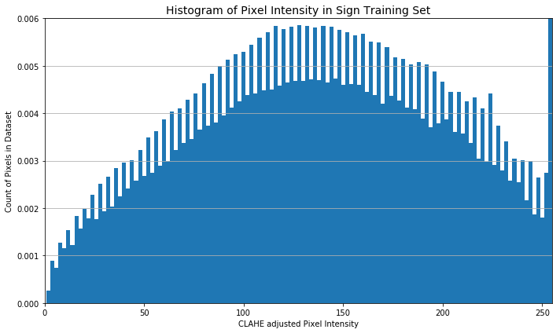

```python
X_gtrain = np.array(X_graytrain)
print('Standardized Grayscale Image Training Set Stats\n===============================================\n',
      'Max value: {:.1f}, '.format( X_gtrain.max()),
      'mean value: {:.1f}, '.format( X_gtrain.mean()),
      'min value: {:.1f}, '.format( X_gtrain.min()),
      'std deviation: {:.1f}\n'.format( X_gtrain.std()),
      'sum of values in set: {:.1f}, '.format( X_gtrain.sum()),
      'mean sum of values per image: {:.1f} '.format( X_gtrain.sum()/len(X_graytrain)))

fig1 = plt.figure(figsize=(10,6))
ax1 = fig1.add_subplot(1,1,1)
ax1.set_title('Histogram of Pixel Intensity in Sign Training Set', fontsize=14)
num_bins = 127
n, bins, patches = ax1.hist(X_gtrain.flatten(), num_bins, normed=True) #density will replace normed but not yet!
ax1.set_xlim(0., 255.)
ax1.set_ylim(0., 0.006)
ax1.grid(which='major', axis='y')
ax1.set_xlabel('CLAHE adjusted Pixel Intensity')
ax1.set_ylabel('Count of Pixels in Dataset')
fig1.tight_layout()
plt.show()
```

#### Code Cell 5: Let's graph how the classes of signs are distributed among the different image sets

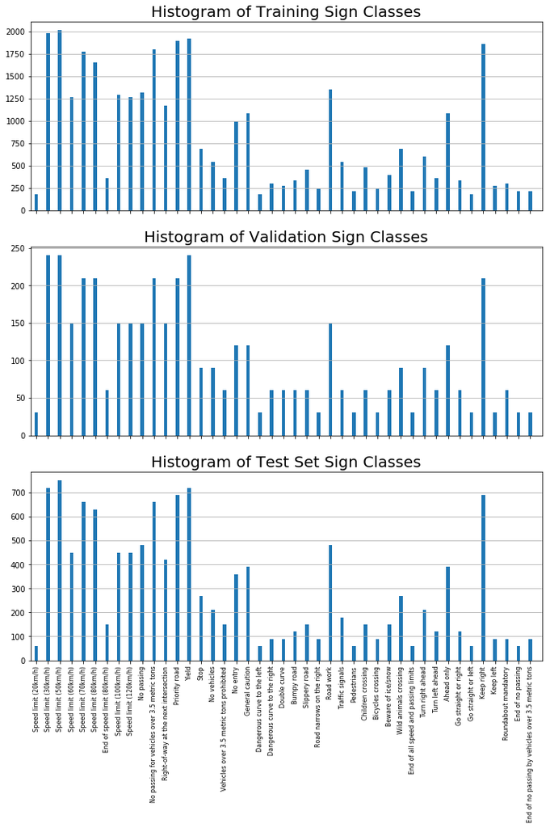

```python
import matplotlib.pyplot as plt
plt.rcParams.update({'figure.max_open_warning': 0})
# Visualizations will be shown in the notebook.
%matplotlib inline

#Print out bar charts of distribution of classes in each set
fig, ax = plt.subplots(ncols=1, nrows=3, figsize=(10,15), frameon=True, squeeze=True, sharex='all')
ax[0].set_title('Histogram of Training Sign Classes', fontsize=20)
n, bins, patches = ax[0].hist(y_train, bins=np.arange(len(signnames)+1), rwidth=.3, align='left')
ax[0].set_xlim(-0.5, len(signnames))
ax[0].set_xticks(np.arange(len(signnames)))
ax[0].grid(which='major', axis='y')

ax[1].set_title('Histogram of Validation Sign Classes', fontsize=20)
n, bins, patches = ax[1].hist(y_valid, bins=np.arange(len(signnames)+1), rwidth=.3, align='left')
ax[1].set_xlim(-0.5, len(signnames))
ax[1].set_xticks(np.arange(len(signnames)))
ax[1].grid(which='major', axis='y')

ax[2].set_title('Histogram of Test Set Sign Classes', fontsize=20)
n, bins, patches = ax[2].hist(y_test, bins=np.arange(len(signnames)+1), rwidth=.3, align='left')
ax[2].set_xlim(-0.5, len(signnames))
ax[2].set_xticks(np.arange(len(signnames)))
ax[2].grid(which='major', axis='y')
ax[2].set_xticklabels(signnames, rotation='vertical', fontsize = 8)
fig.tight_layout(pad=1, w_pad=0.5, h_pad=2.0)
plt.show()
```

We can see that the classes have almost 10 times the amount of samples than are found in other classes

Since unequal representations of classes in the set could lead our model to bias to certain classes of signs, I ran experiments where I only used a limited set which was equalized between the classes. This did not provide better results in my early tests, but could be potentially used to build a more equally distributed augmented set.

#### Code Cell 6: Code to generate the equalized set.

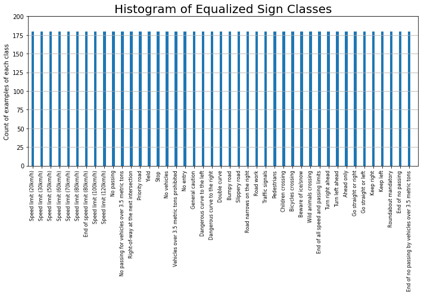

```python
#Flag to equalize number of examples across classes in the training set
equalized_set = False # equalized set did not provide better results

min_set_size = 180
for types in sorted(signtypes, key=int):
    dfs = df[(df['y'] == int(types))].sample(n=min_set_size)
    if int(types) == 0:
        X_equalized = np.asarray(dfs['X_gray'].tolist())
        img_y = np.asarray(dfs['y'].values)
        img_nums = np.asarray(dfs.index.values)
    else:
        X_equalized = np.append(X_equalized, np.asarray(dfs['X_gray'].tolist()), axis=0)
        img_nums = np.append(img_nums, np.asarray(dfs.index.values))
        img_y = np.append(img_y, np.asarray(dfs['y'].values))

X_flat = np.ravel(X_equalized)

#Plot distribution of classes in equalized set
fig, ax = plt.subplots(ncols=1, nrows=1, figsize=(10,7), frameon=True, squeeze=True)
ax.set_title('Histogram of Equalized Sign Classes', fontsize=20)
n, bins, patches = ax.hist(img_y, bins=np.arange(len(signnames)+1), rwidth=.3, align='left')
ax.set_xlim(-0.5, len(signnames))
ax.set_xticks(np.arange(len(signnames)))
ax.grid(which='major', axis='y')
ax.set_xticklabels(signnames, rotation='vertical', fontsize = 8)
ax.set_ylabel('Count of examples of each class')
ax.set_ylim(0., 200.)
fig.tight_layout()
plt.show()
```

#### Code Cell 7: code to generate stats and a histogram of the pixel intensity in the equalized training set.

```
Equalized Standardized Grayscale Image Training Set Stats
 =========================================================
 Max value: 255.0,  mean value: 139.3,  min value: 1.0,  std deviation: 64.7
 sum of values in set: 1104033200,  mean sum of values per image: 142640
```

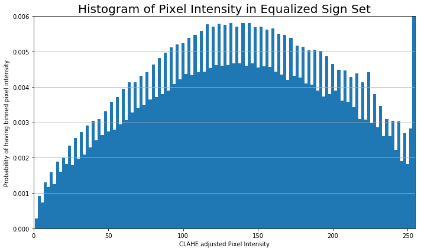

```python
print('Equalized Standardized Grayscale Image Training Set Stats\n',
        '=========================================================\n',
      'Max value: {:.1f}, '.format( X_flat.max()),
      'mean value: {:.1f}, '.format( X_flat.mean()),
      'min value: {:.1f}, '.format( X_flat.min()),
      'std deviation: {:.1f}\n'.format( X_flat.std()),
      'sum of values in set: {:.0f}, '.format( X_flat.sum()),
      'mean sum of values per image: {:.0f} '.format( X_flat.sum()/len(X_equalized)))

#plot pixel intensity distribution in equalized set
fig3 = plt.figure(figsize=(10,6))
ax3 = fig3.add_subplot(1,1,1)
num_bins = 127
ax3.set_title('Histogram of Pixel Intensity in Equalized Sign Set', fontsize=20)
n, bins, patches = ax3.hist(X_flat, num_bins, normed=True)
ax3.grid(which='major', axis='y')
ax3.set_xlim(0., 255.)
ax3.set_ylim(0., 0.006)
ax3.set_xlabel('CLAHE adjusted Pixel Intensity')
ax3.set_ylabel('Probability of having binned pixel intensity')
fig3.tight_layout()
plt.show()
```

#### Code Cell 8: Code to print up a legend of the signtypes using random samples from the training set.

We'll print some in the original color and some in grayscale contrast equalized format.

[figure not shown]

```python
#Print out 'n' random images from each classification in the training set
n_batch = 5 # works best with odd number for centering class title
transparency = 0.7

fig, axes = plt.subplots(ncols=n_batch, nrows=n_classes, figsize=((2*n_batch),2*n_classes),
                         frameon=True, squeeze=True, sharey='all' )
fig.patch.set_facecolor('gray')
fig.patch.set_alpha(transparency)
fig.tight_layout(pad=1, w_pad=0.5, h_pad=2.0)
for types in sorted(signtypes, key=int):
    images = []
    dfs = df[(df['y'] == int(types))].sample(n=n_batch)
    #raw_images = dfs['X_train'].tolist()
    raw_images = dfs['X_gray'].tolist()
    raw_cimages = dfs['X'].tolist()
    img_nums = dfs.index.tolist()
    row_title = "Examples from Sign Class {}: {}".format(types, signtypes[str(types)])
    for i in range(n_batch):
        img_title = "image #: {}".format(img_nums[i])
        grayoutput = raw_images[i].reshape(32,32)
        #axes[int(types),i].imshow(raw_images[i], shape=(2,2))
        if i < ((n_batch-1)/2):
            axes[int(types),i].imshow(raw_cimages[i], shape=(2,2), cmap=None)
        else:
            axes[int(types),i].imshow(grayoutput, shape=(2,2), cmap ='gray')
        axes[int(types),i].set_xlabel(img_title, fontsize=10)
        axes[int(types),i].tick_params( axis='both', which='both',
              bottom='off', left='off', right='off', top='off',
              labelbottom='off', labelleft='off')
        if i == int(n_batch/2):
            axes[int(types),i].set_title(row_title, fontsize=14)
```

The legend demonstrates how the contrast enhanced grayscale images are generally easier to classify (by humans) since the original images are often dark. However, there does appear to be some loss of fidelity in finer aspects of the image like the text- possibly caused by such low initial resolutions. Also solid white backgrounds become very noisy.

### Generate Augmented Data

I decided to augment the data set with distortions of the original training data set - blurring, scaling, rotating, displacing, and perspective distorting (tilting) in the four main directions.

#### Code Cell 9: Code to generate stats on the data set

```
Grayscale Image Pixel data Max:255, Min:1, Mean:139.55498064554658, std dev:64.44478174088184 Range:254, Midlevel: 127.0
```

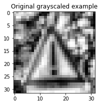

```python
from sklearn.utils import shuffle
import cv2

if equalized_set == True:
    #equalize input data set to 180 images from each signtype.
    X_htrain = X_equalized
else:
    X_htrain = X_gtrain

#calculate stats on Input Imgs
x_data = np.array(X_htrain)
x_data = x_data.flatten()
n = len(X_graytrain)
max_X = x_data.max()
min_X = x_data.min()
mean_X = x_data.mean()
std_X = x_data.std()
range_X = max_X-min_X
midlevel_X = range_X/2
print("Grayscale Image Pixel data Max:{}, Min:{}, Mean:{}, std dev:{} Range:{}, Midlevel: {}"
      .format(max_X, min_X, mean_X, std_X, range_X, midlevel_X))

selected = np.random.randint(len(X_gtrain))
plot_image(X_gtrain[selected].reshape(32,32),"Original grayscaled example")
```

#### Code Cell 10: Code to generate blurred copy of training data set images

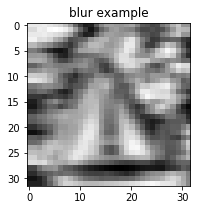

```python
#generate blur set (sideways blur)
X_btrain = []
for img in X_htrain:
    img = img.reshape((32,32))
    size = 3+np.random.randint(5) #(random blur from 3 to 7)
    # generating the kernel
    kernel_motion_blur = np.zeros((size, size))
    kernel_motion_blur[int((size-1)/2), :] = np.ones(size)
    kernel_motion_blur = kernel_motion_blur / size
    # applying the kernel to the input image
    bcl1 = cv2.filter2D(img, -1, kernel_motion_blur)
    bcl2 = np.asarray(bcl1).reshape((32, 32, 1))
    X_btrain.append(bcl2)

plot_image(X_btrain[selected].reshape(32,32),"blur example")
```

#### Code Cell 11: Code to generate scaled copy of training data set images

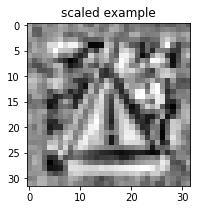

```python
#generate scaled set (apply 90,80,70, or 60% scaling)
X_strain = []
for img in X_htrain:
    img = img.reshape((32,32))
    #scl1 = cv2.copyMakeBorder(img,3,20,3,20,cv2.BORDER_REPLICATE)
    scl1 = graynoise_border(img, border_width=11)
    resize = 1. - (1+np.random.randint(4))/10.
    scl2 = cv2.resize(scl1, None,fx=resize, fy=resize, interpolation = cv2.INTER_CUBIC)
    (h, w) = scl2.shape[:2]
    midcol = int(w / 2)
    midrow = int(h / 2)
    scl2 = scl2[midcol-16:midcol+16, midrow-16:midrow+16]
    scl2 = np.asarray(scl2).reshape((32, 32, 1))
    X_strain.append(scl2)

plot_image(X_strain[selected].reshape(32,32),"scaled example")
```

#### Code Cell 12: Code to generate displaced copy of training data set images

[figure not shown]

```python
#generate displaced set
# move x and y by +-(3 to 7)
X_dtrain = []
for img in X_htrain:
    img = img.reshape((32,32))
    dcl1 = graynoise_border(img, border_width=8)
    #dcl1 = cv2.copyMakeBorder(img,8,8,8,8,cv2.BORDER_REPLICATE)
    movex = ((-1)**np.random.randint(2))*(3+np.random.randint(4))
    movey = ((-1)**np.random.randint(2))*(3+np.random.randint(4))
    dcl1 = dcl1[8-movey:40-movey, 8-movex:40-movex]
    dcl2 = np.asarray(dcl1).reshape((32, 32, 1))
    X_dtrain.append(dcl2)

plot_image(X_dtrain[selected].reshape(32,32),"displaced example")
```

#### Code Cell 13: Code to generate rotated copies of training data set images

[figure not shown]

```python
#generate rotated set with random rotations between 5 to 15 degrees right or left
X_rtrain = []
for img in X_htrain:
    img = img.reshape((32,32))
    rcl1 = graynoise_border(img, border_width=8)
    #rcl1 = cv2.copyMakeBorder(img,8,8,8,8,cv2.BORDER_REPLICATE)
    (h, w) = rcl1.shape[:2]
    center = (w / 2, h / 2)
    angle = ((-1)**(np.random.randint(2))*(np.random.randint(3)+1)*5)
    M = cv2.getRotationMatrix2D(center, angle, 1.0)
    rcl2 = cv2.warpAffine(rcl1, M, (w, h))
    (h, w) = rcl2.shape[:2]
    midcol = int(w / 2)
    midrow = int(h / 2)
    rcl2 = rcl2[midcol-16:midcol+16, midrow-16:midrow+16]
    rcl2 = np.asarray(rcl2).reshape((32, 32, 1))
    X_rtrain.append(rcl2)

plot_image(X_rtrain[selected].reshape(32,32),"rotated example")
```

#### Code Cell 14: Code to generate tilted down copy of training data set images

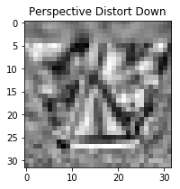

```python
#generate perspective distortion set - tilt down
X_pdtrain = []
for img in X_htrain:
    img = img.reshape((32,32))
    img2 = graynoise_border(img,16)
    pts1 = np.float32([[16,16],[47,16],[16,47],[47,47]])
    pts2 = np.float32([[0,5],[31,5],[7,27],[25,27]])
    M = cv2.getPerspectiveTransform(pts1,pts2)
    pdst = cv2.warpPerspective(img2,M,(32,32))
    pdst = np.asarray(pdst).reshape((32, 32, 1))
    X_pdtrain.append(pdst)

plot_image(X_pdtrain[selected].reshape(32,32),"Perspective Distort Down")
```

#### Code Cell 15: Code to generate tilted left copy of training data set images

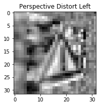

```python
#generate perspective distortion set - tilt left
X_pltrain = []
for img in X_htrain:
    img = img.reshape((32,32))
    img2 = graynoise_border(img,16)
    pts1 = np.float32([[16,16],[47,16],[16,47],[47,47]])
    pts2 = np.float32([[5,0],[27,7],[5,31],[27,25]])
    M = cv2.getPerspectiveTransform(pts1,pts2)
    pdst2 = cv2.warpPerspective(img2,M,(32,32))
    pdst2 = np.asarray(pdst2).reshape((32, 32, 1))
    X_pltrain.append(pdst2)

plot_image(X_pltrain[selected].reshape(32,32),"Perspective Distort Left")
```

#### Code Cell 16: Code to generate tilted right copy of training data set images

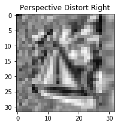

```python
#generate perspective distortion set - tilt right
X_prtrain = []
for img in X_htrain:
    img = img.reshape((32,32))
    img2 = graynoise_border(img,16)
    pts1 = np.float32([[16,16],[47,16],[16,47],[47,47]])
    pts2 = np.float32([[5,7],[27,0],[5,25],[27,31]])
    M = cv2.getPerspectiveTransform(pts1,pts2)
    pdst3 = cv2.warpPerspective(img2,M,(32,32))
    pdst3 = np.asarray(pdst3).reshape((32, 32, 1))
    X_prtrain.append(pdst3)

plot_image(X_prtrain[selected].reshape(32,32),"Perspective Distort Right")
```

#### Code Cell 17: Code to generate tilted up copy of training data set images

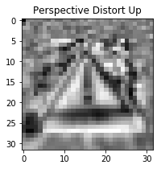

```python
#generate perspective distortion set - tilt up
X_putrain = []
for img in X_htrain:
    img = img.reshape((32,32))
    img2 = graynoise_border(img,16)
    pts1 = np.float32([[16,16],[47,16],[16,47],[47,47]])
    pts2 = np.float32([[7,5],[25,5],[0,27],[31,27]])
    M = cv2.getPerspectiveTransform(pts1,pts2)
    pdst4 = cv2.warpPerspective(img2,M,(32,32))
    pdst4 = np.asarray(pdst4).reshape((32, 32, 1))
    X_putrain.append(pdst4)

plot_image(X_putrain[selected].reshape(32,32),"Perspective Distort Up")
```

#### Code Cell 18: Code to combine augmented training data sets

```python
# combine augmented set
X_htrain = X_gtrain
X_htrain = np.append(X_htrain, X_btrain, axis=0)
X_htrain = np.append(X_htrain, X_strain, axis=0)
X_htrain = np.append(X_htrain, X_dtrain, axis=0)
X_htrain = np.append(X_htrain, X_rtrain, axis=0)
X_htrain = np.append(X_htrain, X_pdtrain, axis=0)
X_htrain = np.append(X_htrain, X_pltrain, axis=0)
X_htrain = np.append(X_htrain, X_prtrain, axis=0)
X_htrain = np.append(X_htrain, X_putrain, axis=0)

# do the same for the labels
if equalized_set == True:
    y_htrain = [img_y,img_y,img_y,img_y,img_y,img_y,img_y,img_y,img_y]
else:
    y_htrain = [y_train,y_train,y_train,y_train,y_train,y_train,y_train,y_train,y_train]
y_htrain = [item for sublist in y_htrain for item in sublist]

print("X_htrain has {} elements".format(len(X_htrain)))
print("y_htrain has {} elements".format(len(y_htrain)))
```

```
X_htrain has 313191 elements
y_htrain has 313191 elements
```

It has been shown that normalizing/standardizing the distribution of the image pixels helps with training.

#### Code Cell 19: Code to apply a normalization so that all images have a standard deviation of 1 and are centered at 0.

```python
#apply standardization to training set
X_sttrain = []
for img in X_htrain:
    cl1 = img
    #cl1 = (img-mean_X)/std_X # using set values for mean and std
    cl1 = (cl1-np.mean(cl1))/np.std(cl1) # using individual values for mean and std
    X_sttrain.append(cl1)

#X_htrain = X_sttrain
X_trainh, y_trainh = shuffle(X_sttrain, y_htrain)

#pickle up normalized grayscale training data
out_set = {}
out_set['features'] = X_trainh
out_set['labels'] = y_trainh
with open('./prepped_data/gntraindata.p', 'wb') as f:
    pickle.dump(out_set,f)
    f.close()
print("Processed Training set pickled up")
```

```
Processed Training set pickled up
```

#### Code Cell 20: Code to preprocess and normalize the validation set

```python
#Preprocess the validation set
X_hvalid =[]
for img in X_valid:
    if use_skimage == True:
        cl, cl1 = imagepipeline(img, clahe='ski', tiles=16, cliplimit = .15)
    else: # cv2
        cl, cl1 = imagepipeline(img)
    #apply standardization
    cl2 = (cl1-np.mean(cl1))/np.std(cl1)
    X_hvalid.append(cl2)

print("X_hvalid has {} elements".format(len(X_hvalid)))
print("y_valid has {} elements".format(len(y_valid)))

#pickle up normalized grayscale validation data
out_set = {}
out_set['features'] = X_hvalid
out_set['labels'] = y_valid
with open('./prepped_data/gnvaliddata.p', 'wb') as f:
    pickle.dump(out_set,f)
    f.close()
print("Processed Validation set pickled up")
```

```
X_hvalid has 4410 elements
y_valid has 4410 elements
Processed Validation set pickled up
```

#### Code Cell 21: Code to preprocess and normalize the test set

```python
#Preprocess the test set
X_htest =[]
for img in X_test:
    if use_skimage == True:
        cl, cl1 = imagepipeline(img, clahe='ski', tiles=16, cliplimit = .15)
    else: # cv2
        cl, cl1 = imagepipeline(img)
    #apply standardization
    cl2 = (cl1-np.mean(cl1))/np.std(cl1)
    X_htest.append(cl2)

print("X_htest has {} elements".format(len(X_htest)))
print("y_test has {} elements".format(len(y_test)))

#pickle up normalized grayscale test data
out_set = {}
out_set['features'] = X_htest
out_set['labels'] = y_test
with open('./prepped_data/gntestdata.p', 'wb') as f:
    pickle.dump(out_set,f)
    f.close()
    print("Processed Test set pickled up")
```

```
X_htest has 12630 elements
y_test has 12630 elements
Processed Test set pickled up
```

#### Code Cell 22: Code to generate some stats and graphs about the augmented training set.

```
Augmented Training Set Stats after Pixel Normalization
 =========================================================
 Max:5.0
 Min:-6.2
 Mean:-0.0
 Std Dev:1.0
 Range:11.2
 Midlevel:-0.6
```

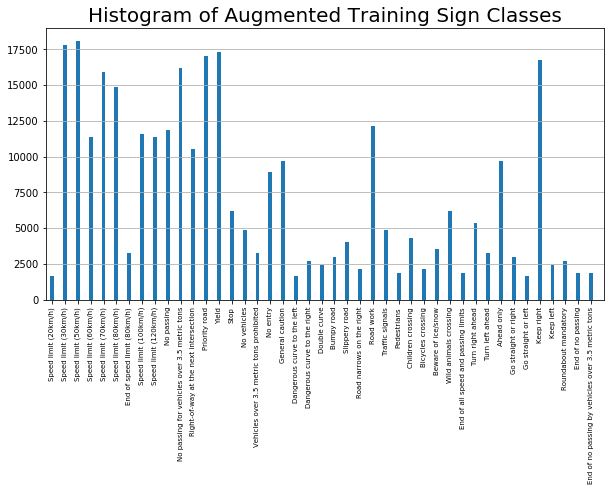

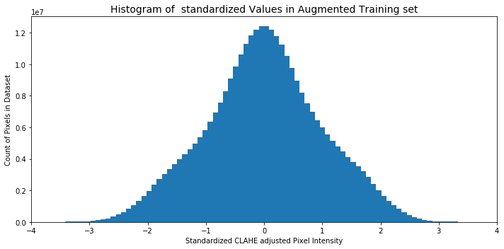

```python
#some details on augmented standardized training set
print("Augmented Training Set Stats after Pixel Normalization \n",
      "=========================================================")
x_data = np.array(X_trainh)
x_data = x_data.flatten()
max_n = x_data.max()
min_n = x_data.min()
mean_n = x_data.mean()
std_n = x_data.std()
range_n = max_n-min_n
midlevel_n = max_n - range_n/2
print(" Max:{:.1f}\n Min:{:.1f}\n Mean:{:.1f}\n Std Dev:{:.1f}\n Range:{:.1f}\n Midlevel:{:.1f}"
      .format(max_n, min_n, mean_n, std_n, range_n, midlevel_n))

fig, ax = plt.subplots(figsize=(10,5), frameon=True, squeeze=True, sharex='all')
ax.set_title('Histogram of Augmented Training Sign Classes', fontsize=20)
n, bins, patches = ax.hist(y_trainh, bins=np.arange(len(signnames)+1), rwidth=.3, align='left')
ax.set_xlim(-0.5, len(signnames))
ax.set_xticks(np.arange(len(signnames)))
ax.grid(which='major', axis='y')
ax.set_xticklabels(signnames, rotation='vertical', fontsize = 7)
fig1.tight_layout()
plt.show()

fig1, ax1 = plt.subplots(figsize=(10,5), frameon=True, squeeze=True)
num_bins = 128
n, bins, patches = ax1.hist(x_data, num_bins)
ax1.set_title('Histogram of  standardized Values in Augmented Training set', fontsize=14)
ax1.set_xlabel('Standardized CLAHE adjusted Pixel Intensity')
ax1.set_ylabel('Count of Pixels in Dataset')
ax1.set_xlim(-4., 4.)
fig1.tight_layout()
plt.show()
```

#### Code Cell 23: Set up Tensorflow

```python
import tensorflow as tf
#using version 1.1 RC nightly build
print(tf.__version__)

config = tf.ConfigProto()
tf.log_device_placement=True
#config.gpu_options.allow_growth = True

useRGBinput = False #switched to grayscale input
```

```
1.1.0-rc0
```

### Model Architecture

This was adapted from the LeNet-5 architecture in the class assignment. The activation functions were switched to ELU from ReLU and Softmax, and also layer1 output was pipelined into Layer 4 without passing through layers 2 and 3 since there were articles about multiscale architectures providing good performance.

#### Code Cell 24: Define the architecture of the network

```python
from tensorflow.contrib.layers import flatten

def MultiScale_LeNet(x):
    # Arguments used for tf.truncated_normal, randomly defines variables for the weights and biases for each layer
    mu = 0
    sigma = 0.1

    #Layer 1: Convolutional. Input = 32x32x1. Output = 28x28x16.
    if useRGBinput == True:
        #For 3 layer color image input
        F1_w = tf.Variable(tf.truncated_normal([5,5,3,16], mean = mu, stddev = sigma))
    else:
        #For 1 layer grayscale image input
        F1_w = tf.Variable(tf.truncated_normal([5,5,1,16], mean = mu, stddev = sigma))
    F1_b = tf.Variable(tf.zeros([16]))
    strides_1x1 = [1,1,1,1]
    strides_2x2 = [1,2,2,1]
    padding_1 = 'VALID'
    L1conv = tf.nn.conv2d(x, F1_w, strides_1x1, padding=padding_1,name='convL1') + F1_b
    # Activation function. (Chose ELU)
    L1elu = tf.nn.elu(L1conv,name='eluL1')
    # Pooling. Input = 28x28x16. Output = 14x14x16.
    P_fs = [1,2,2,1] #pooling filter size
    L1maxpool = tf.nn.max_pool(L1elu, ksize=P_fs, strides=strides_2x2, padding=padding_1, name='maxpoolL1')

    #Layer 2: Convolutional. Input 14x14x16 Output = 10x10x16.
    F2_w = tf.Variable(tf.truncated_normal([5,5,16,16], mean = mu, stddev = sigma))
    F2_b = tf.Variable(tf.zeros([16]))
    L2conv = tf.nn.conv2d(L1maxpool, F2_w, strides_1x1, padding=padding_1,name='convL2') + F2_b
    # Activation function ELU
    L2elu = tf.nn.elu(L2conv,name='eluL2')
    # Pooling. Input = 10x10x16. Output = 5x5x16.
    L2maxpool = tf.nn.max_pool(L2elu, ksize=P_fs, strides=strides_2x2, padding=padding_1, name='maxpoolL2')
    # Flatten. Input = 5x5x16. Output = 400.
    L2flat = tf.contrib.layers.flatten(L2maxpool)

    #Layer 3: Fully Connected. Input = 400. Output = 120.
    F3_w = tf.Variable(tf.truncated_normal([400,120], mean = mu, stddev = sigma))
    F3_b = tf.Variable(tf.zeros([120]))
    L3fc = tf.add(tf.matmul(L2flat,F3_w,name='FCL3'),F3_b)
    # Activation function ELU
    L3elu = tf.nn.elu(L3fc,name='eluL3')
    # Dropout
    L3drop = tf.nn.dropout(L3elu,keep_prob)

    #Layer1a - set up pipeline from L1 to L4 input 14*14*6 Output 3*3*16 = 144
    strides_4x4 = [1,4,4,1]
    P_fs4 = [1,4,4,1] #pooling filter size
    L1Amaxpool = tf.nn.max_pool(L1maxpool, ksize=P_fs4, strides=strides_4x4, padding=padding_1)
    #now flatten to
    L1Aflat = tf.contrib.layers.flatten(L1Amaxpool)
    #add in dropout
    L1Adrop = tf.nn.dropout(L1Aflat,keep_prob)

    #combine L3 output and L1A output
    L3and1A = tf.concat(axis=1, values=[L1Adrop, L3drop])

    #Layer 4: Fully Connected. Input = 264 (120 from layer 3 and 144 from layer 1A). Output = 84.
    F4_w = tf.Variable(tf.truncated_normal([264,84], mean = mu, stddev = sigma))
    F4_b = tf.Variable(tf.zeros([84]))
    L4fc = tf.add(tf.matmul(L3and1A,F4_w,name='FCL4'),F4_b)
    # Activation function ELU
    L4elu = tf.nn.elu(L4fc,name='eluL4')

    # TODO: Layer 5: Fully Connected. Input = 84. Output = 43.
    F5_w = tf.Variable(tf.truncated_normal([84,43], mean = mu, stddev = sigma))
    F5_b = tf.Variable(tf.zeros([43]))
    logits = tf.add(tf.matmul(L4elu,F5_w,name='FCL5'),F5_b)

    return logits, L1conv, L1elu, L1maxpool, L2conv, L2elu, L2maxpool, L1Amaxpool
```

#### Code Cell 25: Code to load the preprocessed data instead of having to run cells 1-23 above.

```python
# Load the preprocessed data from pickle(so reprocessing doesn't have to be run each time)
with open('./prepped_data/gntraindata.p', mode='rb') as f:
    train = pickle.load(f)
    f.close()
with open('./prepped_data/gnvaliddata.p', mode='rb') as f:
    valid = pickle.load(f)
    f.close()
with open('./prepped_data/gntestdata.p', mode='rb') as f:
    test = pickle.load(f)
    f.close()

X_trainh, y_trainh = train['features'], train['labels']
X_validh, y_valid = valid['features'], valid['labels']
X_htest, y_test = test['features'], test['labels']
print("Retrieved prepped data from pickle")
print()
print("X_trainh has {} elements".format(len(X_trainh)))
print("y_trainh has {} elements".format(len(y_trainh)))
print("X_validh has {} elements".format(len(X_validh)))
print("y_valid has {} elements".format(len(y_valid)))
print("X_htest has {} elements".format(len(X_htest)))
print("y_test has {} elements".format(len(y_test)))
```

```
Retrieved prepped data from pickle

X_trainh has 313191 elements
y_trainh has 313191 elements
X_validh has 4410 elements
y_valid has 4410 elements
X_htest has 12630 elements
y_test has 12630 elements
```

#### Code Cell 26: Code defining Model Hyperparameters, Evaluation function, Accuracy and Loss calculations

```python
#Set up Hyper parameters
EPOCHS = 200
BATCH_SIZE = 64

#### Add in decaying learning rate
starter_learning_rate = 0.0007
batches_per_epoch = np.ceil(len(X_train) / BATCH_SIZE)
decay_step = batches_per_epoch * 4
decay_rate = 0.985
global_step = tf.Variable(0, trainable=False)
learning_rate = tf.train.exponential_decay(starter_learning_rate,
                                           global_step,
                                           decay_steps=decay_step,
                                           decay_rate=decay_rate,
                                           staircase=True)
####

# for color input
if useRGBinput == True:
    x = tf.placeholder(tf.float32, (None, 32, 32, 3))
else: #for grayscale input
    x = tf.placeholder(tf.float32, (None, 32, 32, 1))
y = tf.placeholder(tf.int32, (None))

#dropout on training
keep_prob = tf.placeholder(tf.float32)

#set up 43 classes one_hot
one_hot_y = tf.one_hot(y, 43)

# tensors pulled from network
logits, L1conv, L1elu, L1maxpool, L2conv, L2elu, L2maxpool, L1Amaxpool = MultiScale_LeNet(x)

softmax = tf.nn.softmax(logits)

prediction = tf.argmax(logits, 1)

cross_entropy = tf.nn.softmax_cross_entropy_with_logits(logits=logits, labels=one_hot_y)
loss_operation = tf.reduce_mean(cross_entropy)

optimizer = tf.train.AdamOptimizer(learning_rate = learning_rate)
training_operation = optimizer.minimize(loss_operation, global_step)

correct_prediction = tf.equal(tf.argmax(logits, 1), tf.argmax(one_hot_y, 1))
accuracy_operation = tf.reduce_mean(tf.cast(correct_prediction, tf.float32))

saver = tf.train.Saver()

def evaluate(X_data, y_data, prob=0.5):
    num_examples = len(X_data)
    total_accuracy = 0
    predictions = []
    sess = tf.get_default_session()
    for offset in range(0, num_examples, BATCH_SIZE):
        batch_x, batch_y = X_data[offset:offset+BATCH_SIZE], y_data[offset:offset+BATCH_SIZE]
        accuracy, batch_prediction = sess.run([accuracy_operation, prediction], feed_dict={x: batch_x, y: batch_y, keep_prob: prob})
        total_accuracy += (accuracy * len(batch_x))
        predictions.extend(list(batch_prediction))
    return total_accuracy/num_examples, predictions
```

#### Code Cell 27: Let's train the Model

```python
with tf.Session(config=config) as sess:
    sess.run(tf.global_variables_initializer())
    num_examples = len(X_trainh)
    ta = []
    va = []
    losses = []
    print("Training...")
    print()
    for i in range(EPOCHS):
        X_trainh, y_trainh = shuffle(X_trainh, y_trainh)
        for offset in range(0, num_examples, BATCH_SIZE):
            end = offset + BATCH_SIZE
            batch_x, batch_y = X_trainh[offset:end], y_trainh[offset:end]
            _, loss, step = sess.run(
                [training_operation, loss_operation, global_step],
                feed_dict={x: batch_x, y: batch_y, keep_prob: 0.5}
                )

        training_accuracy, _ = evaluate(X_trainh, y_trainh, 0.5)
        validation_accuracy, validation_prediction = evaluate(X_validh, y_valid, 1.0)
        ta.append(training_accuracy)
        va.append(validation_accuracy)
        losses.append(loss)
        print("EPOCH {} ...".format(i+1),
            "Training Accuracy = {:.2f}%,".format(training_accuracy*100),
            "Validation Accuracy = {:.2f}%,".format(validation_accuracy*100),
            "Learning Rate = {:.7f},".format(sess.run(learning_rate)),
            "Loss = {:.3f}".format(loss))

    save_path = saver.save(sess, './traffic_model/MSlenet3')
    print("Model saved in {}.".format(save_path))
    sess.close()
```

```
Training...

EPOCH 1 ... Training Accuracy = 81.17%, Validation Accuracy = 96.87%, Learning Rate = 0.0006792, Loss = 0.777
EPOCH 2 ... Training Accuracy = 85.95%, Validation Accuracy = 97.82%, Learning Rate = 0.0006589, Loss = 0.357
EPOCH 3 ... Training Accuracy = 89.04%, Validation Accuracy = 97.44%, Learning Rate = 0.0006393, Loss = 0.310
EPOCH 4 ... Training Accuracy = 90.84%, Validation Accuracy = 97.69%, Learning Rate = 0.0006203, Loss = 0.318
EPOCH 5 ... Training Accuracy = 91.54%, Validation Accuracy = 98.03%, Learning Rate = 0.0005928, Loss = 0.456
EPOCH 6 ... Training Accuracy = 92.61%, Validation Accuracy = 97.66%, Learning Rate = 0.0005751, Loss = 0.095
EPOCH 7 ... Training Accuracy = 93.02%, Validation Accuracy = 98.05%, Learning Rate = 0.0005580, Loss = 0.127
EPOCH 8 ... Training Accuracy = 93.67%, Validation Accuracy = 98.03%, Learning Rate = 0.0005414, Loss = 0.290
EPOCH 9 ... Training Accuracy = 93.99%, Validation Accuracy = 98.39%, Learning Rate = 0.0005174, Loss = 0.122
EPOCH 10 ... Training Accuracy = 94.34%, Validation Accuracy = 98.28%, Learning Rate = 0.0005020, Loss = 0.075
EPOCH 11 ... Training Accuracy = 94.20%, Validation Accuracy = 98.12%, Learning Rate = 0.0004870, Loss = 0.030
EPOCH 12 ... Training Accuracy = 94.84%, Validation Accuracy = 98.12%, Learning Rate = 0.0004725, Loss = 0.098
EPOCH 13 ... Training Accuracy = 94.87%, Validation Accuracy = 98.05%, Learning Rate = 0.0004516, Loss = 0.210
EPOCH 14 ... Training Accuracy = 95.35%, Validation Accuracy = 98.48%, Learning Rate = 0.0004381, Loss = 0.069
EPOCH 15 ... Training Accuracy = 95.25%, Validation Accuracy = 98.48%, Learning Rate = 0.0004251, Loss = 0.047
EPOCH 16 ... Training Accuracy = 95.50%, Validation Accuracy = 98.23%, Learning Rate = 0.0004124, Loss = 0.127
EPOCH 17 ... Training Accuracy = 95.58%, Validation Accuracy = 98.50%, Learning Rate = 0.0003942, Loss = 0.061
EPOCH 18 ... Training Accuracy = 95.74%, Validation Accuracy = 98.25%, Learning Rate = 0.0003824, Loss = 0.038
EPOCH 19 ... Training Accuracy = 95.91%, Validation Accuracy = 98.25%, Learning Rate = 0.0003710, Loss = 0.217
EPOCH 20 ... Training Accuracy = 95.90%, Validation Accuracy = 98.55%, Learning Rate = 0.0003600, Loss = 0.212
EPOCH 21 ... Training Accuracy = 95.96%, Validation Accuracy = 98.23%, Learning Rate = 0.0003440, Loss = 0.069
EPOCH 22 ... Training Accuracy = 96.13%, Validation Accuracy = 98.41%, Learning Rate = 0.0003338, Loss = 0.097
EPOCH 23 ... Training Accuracy = 96.30%, Validation Accuracy = 98.84%, Learning Rate = 0.0003239, Loss = 0.114
EPOCH 24 ... Training Accuracy = 96.15%, Validation Accuracy = 98.73%, Learning Rate = 0.0003142, Loss = 0.078
EPOCH 25 ... Training Accuracy = 96.37%, Validation Accuracy = 98.32%, Learning Rate = 0.0003003, Loss = 0.217
EPOCH 26 ... Training Accuracy = 96.48%, Validation Accuracy = 98.50%, Learning Rate = 0.0002913, Loss = 0.125
EPOCH 27 ... Training Accuracy = 96.50%, Validation Accuracy = 98.50%, Learning Rate = 0.0002827, Loss = 0.098
EPOCH 28 ... Training Accuracy = 96.49%, Validation Accuracy = 98.28%, Learning Rate = 0.0002742, Loss = 0.354
EPOCH 29 ... Training Accuracy = 96.68%, Validation Accuracy = 98.41%, Learning Rate = 0.0002621, Loss = 0.048
EPOCH 30 ... Training Accuracy = 96.65%, Validation Accuracy = 98.44%, Learning Rate = 0.0002543, Loss = 0.004
EPOCH 31 ... Training Accuracy = 96.82%, Validation Accuracy = 98.71%, Learning Rate = 0.0002467, Loss = 0.205
EPOCH 32 ... Training Accuracy = 96.77%, Validation Accuracy = 98.16%, Learning Rate = 0.0002394, Loss = 0.065
EPOCH 33 ... Training Accuracy = 96.94%, Validation Accuracy = 98.28%, Learning Rate = 0.0002288, Loss = 0.100
EPOCH 34 ... Training Accuracy = 96.94%, Validation Accuracy = 98.80%, Learning Rate = 0.0002219, Loss = 0.417
EPOCH 35 ... Training Accuracy = 97.00%, Validation Accuracy = 98.44%, Learning Rate = 0.0002153, Loss = 0.088
EPOCH 36 ... Training Accuracy = 96.88%, Validation Accuracy = 98.28%, Learning Rate = 0.0002089, Loss = 0.157
EPOCH 37 ... Training Accuracy = 96.96%, Validation Accuracy = 98.44%, Learning Rate = 0.0001997, Loss = 0.089
EPOCH 38 ... Training Accuracy = 97.06%, Validation Accuracy = 98.55%, Learning Rate = 0.0001937, Loss = 0.130
```

[output cut: 148 more lines]

```
EPOCH 187 ... Training Accuracy = 98.03%, Validation Accuracy = 98.87%, Learning Rate = 0.0000012, Loss = 0.077
EPOCH 188 ... Training Accuracy = 98.09%, Validation Accuracy = 98.89%, Learning Rate = 0.0000012, Loss = 0.018
EPOCH 189 ... Training Accuracy = 98.11%, Validation Accuracy = 98.84%, Learning Rate = 0.0000011, Loss = 0.197
EPOCH 190 ... Training Accuracy = 98.10%, Validation Accuracy = 98.84%, Learning Rate = 0.0000011, Loss = 0.018
EPOCH 191 ... Training Accuracy = 98.09%, Validation Accuracy = 98.87%, Learning Rate = 0.0000011, Loss = 0.014
EPOCH 192 ... Training Accuracy = 98.12%, Validation Accuracy = 98.84%, Learning Rate = 0.0000010, Loss = 0.057
EPOCH 193 ... Training Accuracy = 98.10%, Validation Accuracy = 98.87%, Learning Rate = 0.0000010, Loss = 0.006
EPOCH 194 ... Training Accuracy = 98.12%, Validation Accuracy = 98.82%, Learning Rate = 0.0000010, Loss = 0.109
EPOCH 195 ... Training Accuracy = 98.07%, Validation Accuracy = 98.87%, Learning Rate = 0.0000009, Loss = 0.083
EPOCH 196 ... Training Accuracy = 98.08%, Validation Accuracy = 98.87%, Learning Rate = 0.0000009, Loss = 0.027
EPOCH 197 ... Training Accuracy = 98.11%, Validation Accuracy = 98.84%, Learning Rate = 0.0000009, Loss = 0.036
EPOCH 198 ... Training Accuracy = 98.12%, Validation Accuracy = 98.87%, Learning Rate = 0.0000008, Loss = 0.031
EPOCH 199 ... Training Accuracy = 98.09%, Validation Accuracy = 98.87%, Learning Rate = 0.0000008, Loss = 0.083
EPOCH 200 ... Training Accuracy = 98.10%, Validation Accuracy = 98.84%, Learning Rate = 0.0000008, Loss = 0.082
Model saved in ./traffic_model/MSlenet3.
```

#### Code Cell 28: Code to plot simple analysis of Training and Validation accuracies and Loss

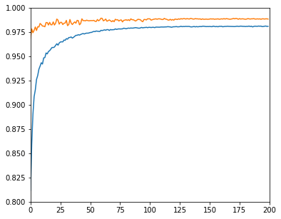

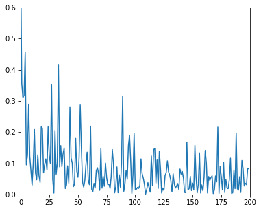

```python
fig = plt.figure(figsize=(6, 5))
plt.plot(ta)
plt.plot(va)
plt.axis([0,EPOCHS, 0.8,1.0])
plt.show()
fig = plt.figure(figsize=(6, 5))
plt.plot(losses)
plt.axis([0,EPOCHS, 0.0,0.6])
plt.show()
```

The graphs show the model training and validation accuracy rising asymptotically to just over 98% and just under 99% respectively, while loss generally decreased, possibly slightly increasing after about 140 epochs. However, the learning rate at that time was so small to probably have much effect, and combined with the dropout assisted in preventing much overfitting (as the validation accuracy did not decrease significantly).

#### Code Cell 29: Code to test how the trained model performs with the test set:

```python
with tf.Session(config=config) as sess:

    sess.run(tf.global_variables_initializer())
    saver.restore(sess, './traffic_model/MSlenet3')
    test_accuracy, test_prediction  = evaluate(X_htest, y_test, 1.0)
    print("Test Accuracy = {:.2f}".format(test_accuracy*100))
    sess.close()
```

```
INFO:tensorflow:Restoring parameters from ./traffic_model/MSlenet3
Test Accuracy = 96.86
```

96.86% accuracy on the test set is fairly good.

#### Code Cell 30: Code to look at examples where the model failed.

```
Out of 12630 test images 397 were incorrectly classified and 12233 were correctly classified
INFO:tensorflow:Restoring parameters from ./traffic_model/MSlenet3
Here are a selction of the incorrectly classified images and the guesses by the model.
```

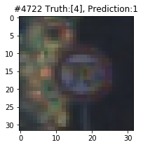

```
AIs ordered choices:   [[1 4 0 8 2]]
AIs ordered certainty: [[ 0.890  0.110  0.000  0.000  0.000]]
```

[figure not shown]

```
AIs ordered choices:   [[ 5  3  2  7 10]]
AIs ordered certainty: [[ 0.989  0.011  0.000  0.000  0.000]]
```

[figure not shown]

```
AIs ordered choices:   [[ 0  1 40 38  3]]
AIs ordered certainty: [[ 0.849  0.114  0.030  0.005  0.001]]
```

[figure not shown]

```
AIs ordered choices:   [[ 3  5  2 10  7]]
AIs ordered certainty: [[ 0.985  0.015  0.000  0.000  0.000]]
```

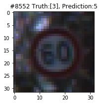

```
AIs ordered choices:   [[5 3 2 7 8]]
AIs ordered certainty: [[ 0.888  0.112  0.000  0.000  0.000]]
```

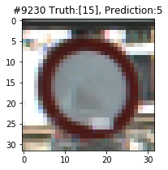

```
AIs ordered choices:   [[ 5 40  7  3 12]]
AIs ordered certainty: [[ 0.324  0.308  0.258  0.090  0.011]]
```

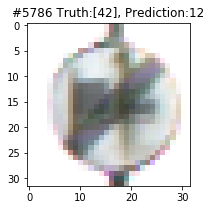

```
AIs ordered choices:   [[12 42 10 17 40]]
AIs ordered certainty: [[ 0.713  0.178  0.057  0.011  0.008]]
```

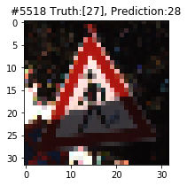

```
AIs ordered choices:   [[28 24 27 26 18]]
AIs ordered certainty: [[ 0.977  0.015  0.008  0.000  0.000]]
```

[figure not shown]

```
AIs ordered choices:   [[ 9 10  2  8  5]]
AIs ordered certainty: [[ 0.704  0.296  0.000  0.000  0.000]]
```

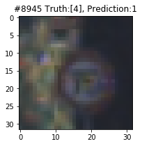

```
AIs ordered choices:   [[1 4 0 7 2]]
AIs ordered certainty: [[ 0.719  0.260  0.015  0.002  0.001]]
```

```python
correct_test_guesses = test_prediction == y_test
incorrect_test_guesses = test_prediction != y_test
print("Out of {} test images {} were incorrectly classified and {} were correctly classified"
      .format(len(y_test), incorrect_test_guesses.astype(int).sum(), correct_test_guesses.astype(int).sum()))

wfilter = np.arange(len(y_test))
mistakes = wfilter * incorrect_test_guesses
mistakes_short = mistakes[mistakes != 0]
mistake_selection = np.random.choice(mistakes_short,10)
sess = tf.Session(config=config)
sess.run(tf.global_variables_initializer())
saver.restore(sess, './traffic_model/MSlenet3')
print("Here are a selction of the incorrectly classified images and the guesses by the model.")
for i in mistake_selection:
    txt = "#{} Truth:{}, Prediction:{}".format(i,y_test[i:i+1],test_prediction[i])
    plot_image(X_test[i], txt, cmap=None)
    #plot_image(X_htest[i].reshape(32,32), txt, cmap='gray')
    softmaxProb = sess.run(softmax, feed_dict={x: X_htest[i:i+1], keep_prob: 1.0})
    (top5cert, top5picks) = sess.run(tf.nn.top_k(tf.constant(softmaxProb), k=5))
    np.set_printoptions(formatter={'float': '{: 0.3f}'.format})
    print("AIs ordered choices:   {}".format(top5picks))
    print("AIs ordered certainty: {}".format(top5cert))
sess.close()
```

It was good to see that in most cases the model picked the correct sign as a second most likely choice. Only with sign 9230, a "No Vehicles" sign, did the model fail to have the corrrect sign label in its top 5 selections.

It was gratifying to me that I would have a hard time correctly guessing what category half of these samples(4722, 2141, 5786, 3124, 8945) belonged to as they were blurred or dark.

Based on these images, it appears that the model might be thrown off, where a human could easily identify the sign, by the presence of shading only on part of the image (image 5518), or by the presence of shiny spots (image 9230 and 12436). The model could potentially be trained to overcome these issues by augmenting the training set with samples including artificially induced spots and shaded areas on the signs.

Let's load up some images from google streetview and see how the model performs. I cut and resized the images to 32x32, but this process could be automated. Just for fun I also want to see how the model reacts to an image of pure noise. This cell loads the images from disk, creates the noise sample, and plots up the color and grayscale contrast equalized images of the signs. I set the class for the noise image to 44 which is outside of the values in Y.